# Exercise 5, Week 5: Dimensionality reduction techniques

Dimensionality reduction techniques exercise is performed on previously merged “human” data set, read from GitHub repo. It consist of combined Human Development and Gender inequality data sets on country level. Description of original data can be found [here](http://hdr.undp.org/en/content/human-development-index-hdi) and [here](http://hdr.undp.org/sites/default/files/hdr2015_technical_notes.pdf), respectively.

```r
# Read human.csv
human <- read.table("https://raw.githubusercontent.com/tuohmas/IODS-project/master/data/human.csv",
                    header = T, sep = ";")
str(human)
```

```
## 'data.frame':    155 obs. of  8 variables:
##  $ edu2_f2m       : num  1.007 0.997 0.983 0.989 0.969 ...
##  $ lab_f2m        : num  0.891 0.819 0.825 0.884 0.829 ...
##  $ life_exp_birth : num  81.6 82.4 83 80.2 81.6 80.9 80.9 79.1 82 81.8 ...
##  $ edu_expected   : num  17.5 20.2 15.8 18.7 17.9 16.5 18.6 16.5 15.9 19.2 ...
##  $ gni_per_capita : int  64992 42261 56431 44025 45435 43919 39568 52947 42155 32689 ...
##  $ mat_mortality  : int  4 6 6 5 6 7 9 28 11 8 ...
##  $ adol_birth_rate: num  7.8 12.1 1.9 5.1 6.2 3.8 8.2 31 14.5 25.3 ...
##  $ repr           : num  39.6 30.5 28.5 38 36.9 36.9 19.9 19.4 28.2 31.4 ...
```

```r
summary(human)
```

```
##     edu2_f2m         lab_f2m       life_exp_birth   edu_expected
##  Min.   :0.1717   Min.   :0.1857   Min.   :49.00   Min.   : 5.40
##  1st Qu.:0.7264   1st Qu.:0.5984   1st Qu.:66.30   1st Qu.:11.25
##  Median :0.9375   Median :0.7535   Median :74.20   Median :13.50
##  Mean   :0.8529   Mean   :0.7074   Mean   :71.65   Mean   :13.18
##  3rd Qu.:0.9968   3rd Qu.:0.8535   3rd Qu.:77.25   3rd Qu.:15.20
##  Max.   :1.4967   Max.   :1.0380   Max.   :83.50   Max.   :20.20
##  gni_per_capita   mat_mortality    adol_birth_rate       repr
##  Min.   :   581   Min.   :   1.0   Min.   :  0.60   Min.   : 0.00
##  1st Qu.:  4198   1st Qu.:  11.5   1st Qu.: 12.65   1st Qu.:12.40
##  Median : 12040   Median :  49.0   Median : 33.60   Median :19.30
##  Mean   : 17628   Mean   : 149.1   Mean   : 47.16   Mean   :20.91
##  3rd Qu.: 24512   3rd Qu.: 190.0   3rd Qu.: 71.95   3rd Qu.:27.95
##  Max.   :123124   Max.   :1100.0   Max.   :204.80   Max.   :57.50
```

```r
# Access GGally
library(tidyverse)
library(GGally)
```

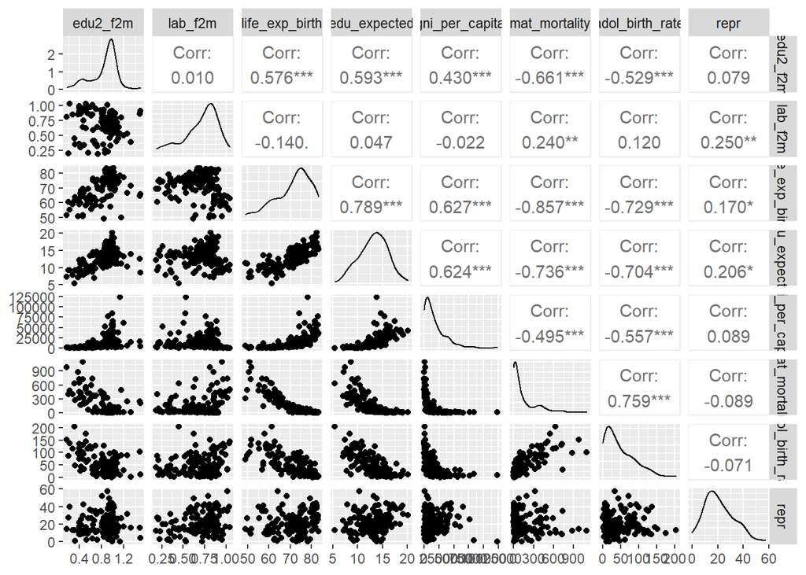

```r
# visualize the 'human_' variables
GGally::ggpairs(human)
```

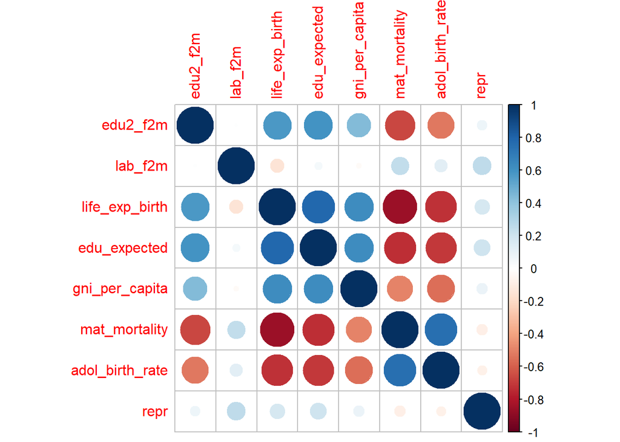

```r
# compute the correlation matrix and visualize it with corrplot
cor(human) %>% corrplot::corrplot()
```

## Principal Component Analysis

```r
# perform principal component analysis (with the SVD method)
pca_human <- prcomp(human)
summary(pca_human)
```

```
## Importance of components:
##                              PC1      PC2   PC3   PC4   PC5   PC6    PC7    PC8
## Standard deviation     1.854e+04 185.5219 25.19 11.45 3.766 1.566 0.1912 0.1591
## Proportion of Variance 9.999e-01   0.0001  0.00  0.00 0.000 0.000 0.0000 0.0000
## Cumulative Proportion  9.999e-01   1.0000  1.00  1.00 1.000 1.000 1.0000 1.0000
```

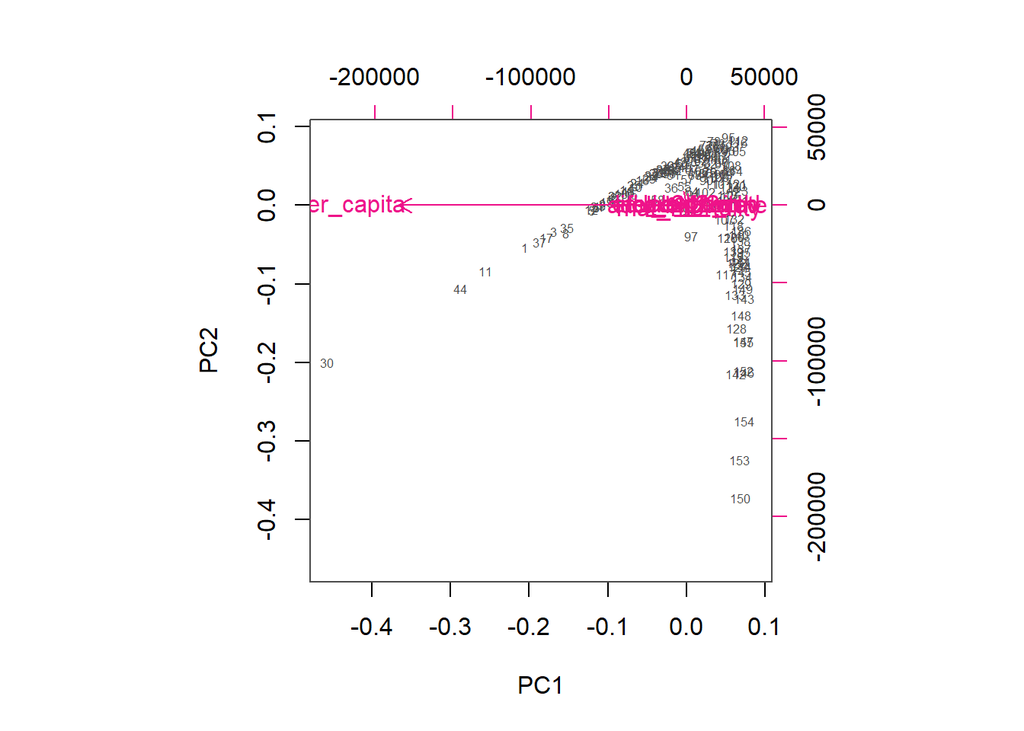

```r
# draw a biplot of the principal component representation and the original variables
biplot(pca_human, choices = 1:2, cex = c(0.5, 0,5),col = c("grey30", "deeppink2"))
```

```r
# Exploring the variances of human variables
library(psych)
describe(human)
```

```
##                 vars   n     mean       sd   median  trimmed      mad    min
## edu2_f2m           1 155     0.85     0.24     0.94     0.87     0.12   0.17
## lab_f2m            2 155     0.71     0.20     0.75     0.73     0.17   0.19
## life_exp_birth     3 155    71.65     8.33    74.20    72.40     7.56  49.00
## edu_expected       4 155    13.18     2.84    13.50    13.24     2.97   5.40
## gni_per_capita     5 155 17627.90 18543.85 12040.00 14552.58 13337.47 581.00
## mat_mortality      6 155   149.08   211.79    49.00   104.70    63.75   1.00
## adol_birth_rate    7 155    47.16    41.11    33.60    41.62    35.73   0.60
## repr               8 155    20.91    11.49    19.30    20.32    11.42   0.00
##                       max     range  skew kurtosis      se
## edu2_f2m             1.50      1.33 -0.76     0.55    0.02
## lab_f2m              1.04      0.85 -0.87     0.05    0.02
## life_exp_birth      83.50     34.50 -0.76    -0.15    0.67
## edu_expected        20.20     14.80 -0.20    -0.34    0.23
## gni_per_capita  123124.00 122543.00  2.14     6.83 1489.48
## mat_mortality     1100.00   1099.00  2.03     4.16   17.01
## adol_birth_rate    204.80    204.20  1.13     0.89    3.30
## repr                57.50     57.50  0.55    -0.10    0.92
```

```r
rev(sort(summarise_if(human, is.numeric, var)))
```

```
##   gni_per_capita mat_mortality adol_birth_rate     repr life_exp_birth
## 1      343874462      44854.83        1690.201 131.9683       69.42328
##   edu_expected  edu2_f2m    lab_f2m
## 1     8.067024 0.0583897 0.03951293
```

According to the summary, The first principal component is capturing unusually high proportion of the total variance in unstandardized human data, more than 99,99 per cent. This very skewed result is reflected also in the biplot:

How accurate is this pictur? We know that Pricipal Component Analysis is sensitive to the relative sclaing of original features, and is easily tipped off by variables that have larger variance compared to ones with smaller variance. We might deduce that GNI per capita dominates other, and indeed, its variance (343874462) is many orders of magnitudes higher than the next one, maternal mortality (44854.83).

Let’s therefore standardize (scale) our human data before performing any PCA.

```r
# standardize the variables
human_std <- scale(human)

# print out summaries of the standardized variables
summary(human_std)
```

```
##     edu2_f2m          lab_f2m        life_exp_birth     edu_expected
##  Min.   :-2.8189   Min.   :-2.6247   Min.   :-2.7188   Min.   :-2.7378
##  1st Qu.:-0.5233   1st Qu.:-0.5484   1st Qu.:-0.6425   1st Qu.:-0.6782
##  Median : 0.3503   Median : 0.2316   Median : 0.3056   Median : 0.1140
##  Mean   : 0.0000   Mean   : 0.0000   Mean   : 0.0000   Mean   : 0.0000
##  3rd Qu.: 0.5958   3rd Qu.: 0.7350   3rd Qu.: 0.6717   3rd Qu.: 0.7126
##  Max.   : 2.6646   Max.   : 1.6632   Max.   : 1.4218   Max.   : 2.4730
##  gni_per_capita    mat_mortality     adol_birth_rate        repr
##  Min.   :-0.9193   Min.   :-0.6992   Min.   :-1.1325   Min.   :-1.8203
##  1st Qu.:-0.7243   1st Qu.:-0.6496   1st Qu.:-0.8394   1st Qu.:-0.7409
##  Median :-0.3013   Median :-0.4726   Median :-0.3298   Median :-0.1403
##  Mean   : 0.0000   Mean   : 0.0000   Mean   : 0.0000   Mean   : 0.0000
##  3rd Qu.: 0.3712   3rd Qu.: 0.1932   3rd Qu.: 0.6030   3rd Qu.: 0.6127
##  Max.   : 5.6890   Max.   : 4.4899   Max.   : 3.8344   Max.   : 3.1850
```

```r
# perform principal component analysis (with the SVD method)
pca_human <- prcomp(human_std)

# create and print out a summary of pca_human
summary <- summary(pca_human)
summary
```

```
## Importance of components:
##                           PC1    PC2     PC3     PC4     PC5     PC6     PC7
## Standard deviation     2.0708 1.1397 0.87505 0.77886 0.66196 0.53631 0.45900
## Proportion of Variance 0.5361 0.1624 0.09571 0.07583 0.05477 0.03595 0.02634
## Cumulative Proportion  0.5361 0.6984 0.79413 0.86996 0.92473 0.96069 0.98702
##                            PC8
## Standard deviation     0.32224
## Proportion of Variance 0.01298
## Cumulative Proportion  1.00000
```

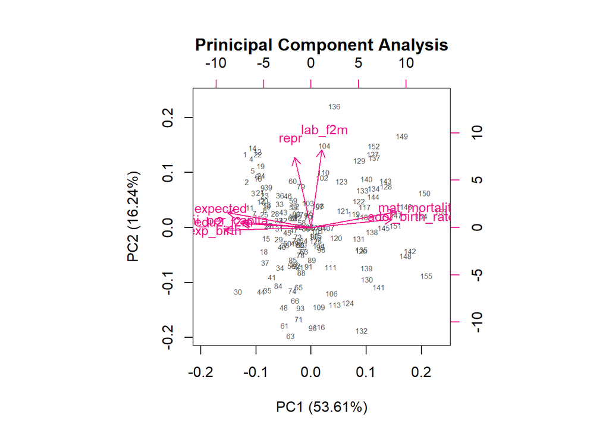

```r
# rounded percetanges of variance captured by each PC
pca_pr <- round(100*summary$importance[2, ], digits = 2)

# create object pc_lab to be used as axis labels
pc_lab <- paste0(names(pca_pr), " (", pca_pr, "%)")

# draw a biplot of the principal component representation and the original variables
biplot(pca_human, choices = 1:2, cex = c(0.5, 0.9),col = c("grey30", "deeppink2"), xlab = pc_lab[1], ylab = pc_lab[2], main = "Prinicipal Component Analysis")
```

For standardized human data, first PC captures much more believable proportion of total variance in data, about 54%, and together with PC2, about 70%. Including more than two PCs would benefit us only marginally as the total variance grows by less than ten per cent with each new dimensions we introduce.

Biplotting the first two principal components tells us that:

- PC1 is contributed by six variables (small angel between these features and PC1 axis): **(edu_expected)**, **(life_exp_birth)**, **(gni_per_capita)**, and **(edu2_f2m)**, that are highly positively correlated together, and **(mat_mortality)**, **(adol_birth_rate)**, that are highly and positively correlated to one another, and negatively correlated to the former four.
- PC2 is contributed by **female shares of parliamentary seats (repr)** and **female vs male labour force participation rate ratio (lab_f2m)**, that are minimally to other six variables (arrows at almost righ angles)
- Most of the variables have similarly large standard devations (arrow length)

There is no clear cut way to interpret our two PCs. However, it seems that [UN designated dimensions](http://hdr.undp.org/sites/default/files/hdr2015_technical_notes.pdf)“A decent standard of living”, “Health” and “Education” are better represented on PC1, whereas PC2 is primarily composed on indicators that measure “Empowerment” and “Labour market”.